# Data Visualisation: Student Project (Python)

#### Matriculation number: 22300141

## 1. Import packages

Importing all the required packages:

```python
import matplotlib.pyplot as plt
import pandas as pd
import numpy as np
from matplotlib.gridspec import GridSpec
from collections import defaultdict
from matplotlib import colormaps
```

## 2. Exercise 1

### 2.1. Version A

Loading the datasets:

```python
df_annotations = pd.read_csv('10_project_data_annotation.csv') # Annotations dataset
df_signals = pd.read_csv('10_project_data_signals.csv') # Signals dataset
```

Creating the plot:

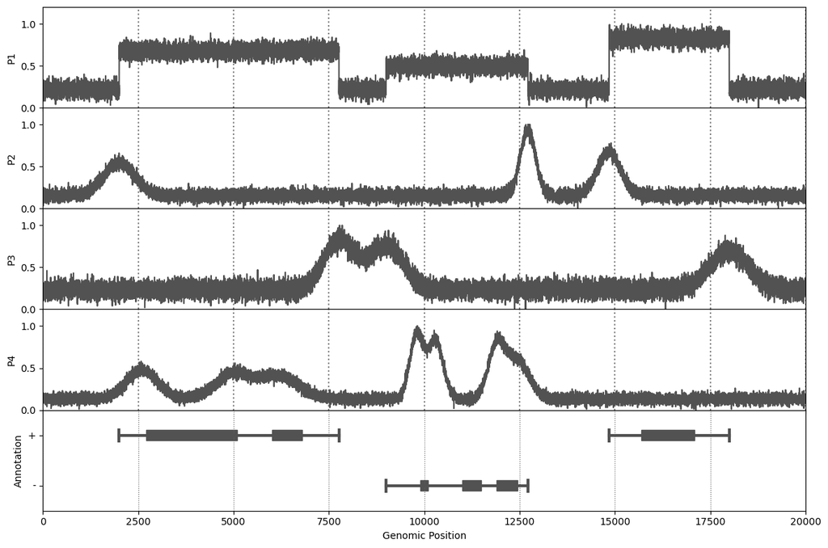

```python
fig, axs = plt.subplots(5, 1, # Creates figure with 5 vertically stacked plots
                        figsize=(12, 8), # Specifies figure size
                        sharex=True, # X-axis is shared
                        gridspec_kw={'height_ratios': [1, 1, 1, 1, 1], 'hspace': 0.0})  # Specificies relative heights and no horizontal space between them

# Plotting signals for each protein
proteins = ['P1', 'P2', 'P3', 'P4']  # Lists proteins to plot

for i, protein in enumerate(proteins):
    axs[i].plot(df_signals.index, df_signals[protein], color='#525252')  # Plots the signal for each protein in its respective subplot
    axs[i].set_ylim(0, 1)  # Sets y-axis limits from 0 to 1
    axs[i].set_yticks([0, 0.5, 1])  # Sets y-axis ticks at 0, 0.5, and 1
    axs[i].set_ylabel(protein)  # Labels y-axis with the protein name

# Filtering exons and transcripts
exons = df_annotations.loc[df_annotations['type'] == 'exon'] # Filters exons from annotations dataframe
transcripts = df_annotations.loc[df_annotations['type'] == 'transcript'] # Filters transcripts from annotations dataframe

# Plotting transcripts as horizontal lines with start and end markers
for _, transcript in transcripts.iterrows():
    strand = transcript['strand']
    y_pos = 1 if strand == '+' else 0  # Determines y-position based on strand
    transcript_start = transcript['start']
    transcript_stop = transcript['stop']

    axs[4].plot([transcript_start, transcript_stop], [y_pos, y_pos], color='#525252', linestyle='-', linewidth=3)  # Plots horizontal line showing transcript
    axs[4].plot(transcript_start, y_pos, marker='|', markersize=15, markeredgewidth=3, color='#525252')  # Marks start of transcript
    axs[4].plot(transcript_stop, y_pos, marker='|', markersize=15, markeredgewidth=3, color='#525252')  # Marks end of transcript

# Plotting exon boxes
for _, exon in exons.iterrows():
    start, stop = exon['start'], exon['stop']
    width = stop - start
    strand = exon['strand']
    y_pos = 1 if strand == '+' else 0  # Determines y-position based on strand
    axs[4].barh(y_pos, width, left=start, height=0.2, color='#525252', edgecolor='#525252')  # Draws a horizontal bar representing exon

# Annotation plot settings
axs[4].set_ylim(-0.5, 1.5)  # Sets y-axis limits to center annotations
axs[4].set_yticks([0, 1])  # Sets y-axis ticks at 0 and 1
axs[4].set_yticklabels(['-', '+'])  # Labels y-axis ticks as '-' and '+'
axs[4].set_ylabel('Annotation')  # Sets y-axis label to 'Annotation'
axs[4].set_xlabel('Genomic Position')  # Sets x-axis label to 'Genomic Position'
axs[4].set_xlim(0, 20000)  # Sets x-axis limits from 0 to 20000
axs[4].grid(axis='x', linestyle='dotted', color='#636363')  # Adds vertical dotted grid lines

# Adding vertical dotted grid lines to signal subplots
for ax in axs[0:4]:
    ax.set_ylim(0, 1.2)  # Sets y-axis limits from 0 to 1.2
    ax.grid(axis='x', linestyle='dotted', color='gray', linewidth=1.5)  # Adds vertical dotted grid lines

plt.rcParams.update({'font.size': 12})  # Updates plot font size

plt.tight_layout()  # Adjusts subplots to fit into the figure area
plt.show()  # Displays the plot
```

### 2.2. Version B

Creating the plot:

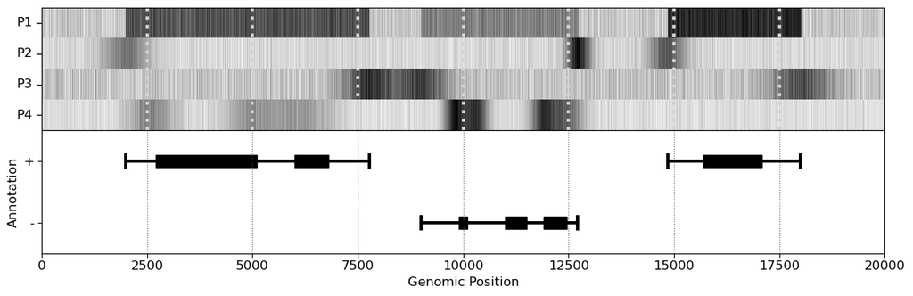

```python
fig, axs = plt.subplots(2, 1, # Creates a figure with 2 vertically stacked subplots
                        figsize=(12, 4), # Specifies figure width and height
                        sharex=True, # Shared X-axis
                        gridspec_kw={'height_ratios': [1, 1], 'hspace': 0.0})  # Equal heights and no horizontal space between them

# Stacks signals for P1, P2, P3, and P4 vertically into combined array
signals_combined = np.vstack([df_signals[protein] for protein in ['P1', 'P2', 'P3', 'P4']])

# Plotting combined signals for P1, P2, P3, and P4
heatmap = axs[0].imshow(signals_combined, aspect="auto", cmap="gray_r", interpolation='none')  # Displays combined signals as a heatmap
axs[0].set_yticks(np.arange(len(['P1', 'P2', 'P3', 'P4'])))  # Sets y-axis ticks for each protein
axs[0].set_yticklabels(['P1', 'P2', 'P3', 'P4'], va='center')  # Labels y-axis ticks with protein names
axs[0].tick_params(axis='y', length=5, width=1)  # Adds y-axis ticks
axs[0].grid(axis='x', linestyle='dotted', color='lightgray', linewidth=3)  # Adds vertical dotted grid lines

# Filtering exons and transcripts
exons = df_annotations.loc[df_annotations['type'] == 'exon'] # Filters exons from annotations dataframe
transcripts = df_annotations.loc[df_annotations['type'] == 'transcript'] # Filters transcripts from annotations dataframe

# Plotting transcripts as horizontal lines with start and end markers
for _, transcript in transcripts.iterrows():
    strand = transcript['strand']
    y_pos = 1 if strand == '+' else 0  # Determines y-position based on strand
    transcript_start = transcript['start']
    transcript_stop = transcript['stop']

    axs[1].plot([transcript_start, transcript_stop], [y_pos, y_pos], color='black', linestyle='-', linewidth=3)  # Plots horizontal line for transcript
    axs[1].plot(transcript_start, y_pos, marker='|', markersize=15, markeredgewidth=3, color='black')  # Marks start of transcript
    axs[1].plot(transcript_stop, y_pos, marker='|', markersize=15, markeredgewidth=3, color='black')  # Marks end of transcript

# Plotting exon boxes
for _, exon in exons.iterrows():
    start, stop = exon['start'], exon['stop']
    width = stop - start
    strand = exon['strand']
    y_pos = 1 if strand == '+' else 0  # Determines y-position based on strand
    axs[1].barh(y_pos, width, left=start, height=0.2, color='black', align='center', edgecolor='black')  # Draws a horizontal bar representing exon

# Annotation plot settings
axs[1].set_ylim(-0.5, 1.5)  # Sets y-axis limits to center annotations
axs[1].set_yticks([0, 1])  # Sets y-axis ticks at 0 and 1
axs[1].set_yticklabels(['-', '+'])  # Labels y-axis ticks as '-' and '+'
axs[1].set_ylabel('Annotation')  # Sets y-axis label to 'Annotation'
axs[1].set_xlabel('Genomic Position')  # Sets x-axis label to 'Genomic Position'
axs[1].set_xlim(0, 20000)  # Sets x-axis limits from 0 to 20000
axs[1].grid(axis='x', linestyle='dotted', color='#636363')  # Adds vertical dotted grid lines

plt.rcParams.update({'font.size': 12})  # Updates plot font size

plt.tight_layout()  # Adjusts subplots to fit into the figure area
plt.show()  # Displays the plot
```

### 2.3. Version C

Creating the plot:

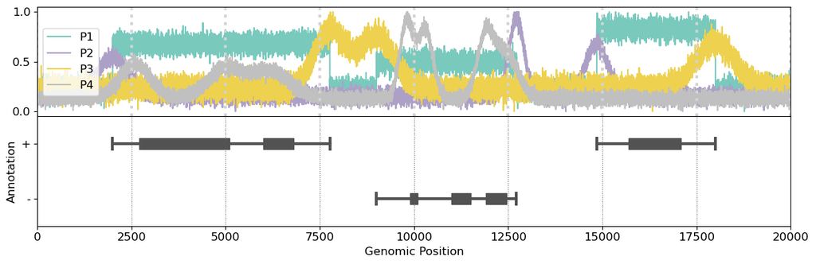

```python
fig, axs = plt.subplots(2, 1, #Creates a figure and 2 vertically stacked subplots
                        figsize=(12, 4), # Figure width and height
                        sharex=True, # Shared x-axis
                        gridspec_kw={'height_ratios': [1, 1], 'hspace': 0.0})  # Equal heights and no horizontal space between them

# Plotting combined signals for P1, P2, P3, and P4 in the first subplot
proteins = ['P1', 'P2', 'P3', 'P4']  # Lists proteins to plot
colors = ['#79c9bd', '#ada0c7', '#eed14f', '#c0c0c0']  # Lists colors for each protein

for protein, color in zip(proteins, colors):
    axs[0].plot(df_signals.index, df_signals[protein], label=protein, color=color, zorder=0)  # Plots signal for each protein

# Annotation plot settings
axs[1].set_ylim(-0.5, 1.5)  # Sets y-axis limits to center annotations
axs[1].set_yticks([0, 1])  # Sets y-axis ticks at 0 and 1
axs[1].set_yticklabels(['-', '+'])  # Labels y-axis ticks as '-' and '+'
axs[1].set_ylabel('Annotation')  # Sets y-axis label to 'Annotation'
axs[1].set_xlabel('Genomic Position')  # Sets x-axis label to 'Genomic Position'
axs[1].set_xlim(0, 20000)  # Sets x-axis limits from 0 to 20000
axs[1].grid(axis='x', linestyle='dotted', color='#636363')  # Adds vertical dotted grid lines

# Filtering exons and transcripts
exons = df_annotations.loc[df_annotations['type'] == 'exon'] # Filters exons from annotations dataframe
transcripts = df_annotations.loc[df_annotations['type'] == 'transcript'] # Filters transcripts from annotations dataframe

# Plotting transcripts as horizontal lines with start and end markers
for idx, transcript in transcripts.iterrows():
    strand = transcript['strand']
    y_pos = 1 if strand == '+' else 0  # Determines y-position based on strand
    transcript_start = transcript['start']
    transcript_stop = transcript['stop']

    axs[1].plot([transcript_start, transcript_stop], [y_pos, y_pos], color='#525252', linestyle='-', linewidth=3)  # Plots horizontal line for transcript
    axs[1].plot(transcript_start, y_pos, marker='|', markersize=15, markeredgewidth=3, color='#525252')  # Marks the start of the transcript
    axs[1].plot(transcript_stop, y_pos, marker='|', markersize=15, markeredgewidth=3, color='#525252')  # Marks the end of the transcript

# Plotting exon boxes
for idx in exons.index:
    exon = exons.loc[idx]
    start, stop = exon['start'], exon['stop']
    width = stop - start
    strand = exon['strand']
    y_pos = 1 if strand == '+' else 0  # Determines y-position based on strand
    axs[1].barh(y_pos, width, left=start, height=0.2, color='#525252', align='center', edgecolor='#525252')  # Draws a horizontal bar representing the exon

# Adding legend to the first subplot, position it inside the plot aligned to the left
axs[0].legend(loc='center left', bbox_to_anchor=(0, 0.5))

# Adds vertical dotted grid lines with specified order
axs[0].grid(axis='x', linestyle='dotted', color='lightgray', linewidth=3, zorder=1)

plt.rcParams.update({'font.size': 12})  # Updates plot font size
plt.tight_layout()  # Adjusts subplots to fit into the figure area
plt.show()  # Displays the plot
```

## 2.4. Discussion

The three versions present the same data in different ways.

**Version A** exhibits clarity in individual trends since each protein signal is clearly separated. This makes it easy to identify trends and patterns within individual datasets and allows for fine-grained analysis since the peaks and fluctuations are preserved. However, this layout takes up more vertical space, especially when there are too many parameters to display, and could lead to a cluttered and overwhelming presentation. Moreover, the parameters' separation into different plots can make comparing trends challenging.

**Version B** exhibits an efficient use of space and allows all protein signals to be visualised simultaneously, using a heatmap, without much scrolling. Heatmaps make it easier to spot overall patterns and anomalies at a glance which makes it easier to compare values across all parameters. However, since heatmaps provide a general overview, they can obscure specific details and smaller fluctuations in the data. Moreover, interpreting colors in heatmaps usually require a legend or additional context for those that are not familiar with the data.

A unified view of all protein signals together is beneficial for identifying correlations. **Version C** allows for direct comparison between the protein signals which makes it easy to see how they relate to one another. Moreover, it uses less space compared to separated plots in version A which makes the presentation more compact. Nevertheless, with multiple lines overlapping each other, distinguishing between individual trends is challenging, especially with similar values. It also relies heavily on color differentiation, which could be problematic for colorblind viewers.

Overall, version A is suitable for a detailed analysis but can be challenging for comparison and space efficiency. Version B offers a comparative and compact overview but loses detail and requires color interpretation, and version C facilities comparison with a unified view but suffers from overlapping lines and color dependency.

## 3. Exercise 2

Loading the datasets:

```python
df_scatter = pd.read_csv('10_project_data_scatter.csv') # Dataset for scatter plot
df_barplot = pd.read_csv('10_project_data_barplot.csv') # Dataset for bar plot
```

Defining a function to create the **scatter plot**:

```python
def scatter_plot(df_scatter, ax):
    ax.scatter(df_scatter['x1'], df_scatter['x2'], s=100, edgecolor='black', facecolor='none', alpha=0.5, marker='o')  # Plots scatter plot of x1 vs x2
    ax.set_xlabel(r'$X_1$', fontsize=14)  # Sets x-axis label with formatting
    ax.set_ylabel(r'$X_2$', fontsize=14)  # Sets y-axis label with formatting
    ax.grid(axis='both', linestyle=':', linewidth=1.5, color='lightgray', zorder=3)  # Adds grid lines with dotted style, specified color, and z-order
```

Defining a function to create the **bar plot**:

```python
def grouped_bar_plot(df_barplot, ax):
    df_barplot.rename(columns={'Unnamed: 0': 'Labels'}, inplace=True)  # Renames the first unnamed column to 'Labels'

    # Bar width and position adjustments
    bar_width = 0.1  # Sets the width of each bar
    spacing_within_group = 0.01  # Sets small space between bars within each group
    spacing_bw_groups = 0.3  # Sets space between groups of bars

    # Computing positions
    num_bars = len(df_barplot.columns) - 1  # Calculates the number of bars per group, excluding the label column
    positions = []  # Initializes the list for bar positions
    for i in range(len(df_barplot)):
        group_start = i * (num_bars * bar_width + spacing_within_group * (num_bars - 1) + spacing_bw_groups)  # Computes starting position for each group
        for j in range(num_bars):
            positions.append(group_start + j * (bar_width + spacing_within_group))  # Computes position for each bar within a group

    positions = np.array(positions).reshape(len(df_barplot), num_bars)  # Reshapes positions array to match the number of groups and bars

    # Plotting the bars
    ax.bar(positions[:, 0], df_barplot['condition_a_sample_1'], bar_width, label='Condition', color='black', zorder=2)  # Plots bars for condition_a_sample_1
    ax.bar(positions[:, 1], df_barplot['condition_a_sample_2'], bar_width, color='black', zorder=3)  # Plots bars for condition_a_sample_2
    ax.bar(positions[:, 2], df_barplot['control'], bar_width, label='Control', color='red', zorder=4)  # Plots bars for control

    ax.set_ylabel('Number of events')  # Sets y-axis label

    # Adjusting xticks to be in the center of each group
    group_centers = positions.mean(axis=1)  # Computes the center position for each group
    custom_labels = ['X → Y', 'X → Z', 'Y → X', 'Y → Z']  # Customizes labels for x-axis
    ax.set_xticks(group_centers)  # Sets x-ticks at group centers
    ax.set_xticklabels(custom_labels, fontstyle='italic')  # Labels x-ticks with custom labels in italic font

    # Adding horizontal dotted grid lines behind the bars
    ax.yaxis.grid(True, linestyle=':', color='#bdbdbd', linewidth=1.5, zorder=0)  # Adds y-axis grid lines with dotted style and specified color
```

Defining a function to create the **heatmap and annotations plot**:

```python
def heatmap_annotations(df_signals, df_annotations, ax):

    signals_combined = np.vstack([df_signals[protein] for protein in ['P1', 'P2', 'P3', 'P4']])  # Combines signals for P1, P2, P3, and P4 into one array

    # Plotting combined signals for P1, P2, P3, and P4
    heatmap = ax[0].imshow(signals_combined, aspect="auto", cmap="gray_r", interpolation='none')  # Displays heatmap of combined signals
    ax[0].set_yticks(np.arange(len(['P1', 'P2', 'P3', 'P4'])))  # Sets y-tick positions for the heatmap
    ax[0].set_yticklabels(['P1', 'P2', 'P3', 'P4'], va='center')  # Sets y-tick labels for the heatmap
    ax[0].tick_params(axis='y', length=5, width=1)  # Adds y-axis ticks
    ax[0].tick_params(axis='x', length=0)  # Removes x-axis ticks
    ax[0].set_xticklabels([])  # Sets x-tick labels to an empty list
    ax[0].grid(axis='x', linestyle='dotted', color='lightgray', linewidth=3)  # Adds vertical grid lines

    # Filtering exons and transcripts
    exons = df_annotations.loc[df_annotations['type'] == 'exon'] # Filters exons from annotations dataframe
    transcripts = df_annotations.loc[df_annotations['type'] == 'transcript'] # Filters transcripts from annotations dataframe

    # Plotting transcripts as horizontal lines
    for _, transcript in transcripts.iterrows():
        strand = transcript['strand']
        y_pos = 1 if strand == '+' else 0  # Determines y-position based on strand
        transcript_start = transcript['start']
        transcript_stop = transcript['stop']

        ax[1].plot([transcript_start, transcript_stop], [y_pos, y_pos], color='black', linestyle='-', linewidth=3)  # Plots horizontal line for each transcript

        ax[1].plot(transcript_start, y_pos, marker='|', markersize=15, markeredgewidth=3, color='black')  # Adds start marker for each transcript
        ax[1].plot(transcript_stop, y_pos, marker='|', markersize=15, markeredgewidth=3, color='black')  # Adds stop marker for each transcript

    # Plotting exon boxes
    for _, exon in exons.iterrows():
        start, stop = exon['start'], exon['stop']
        width = stop - start
        strand = exon['strand']
        y_pos = 1 if strand == '+' else 0  # Determines y-position based on strand
        ax[1].barh(y_pos, width, left=start, height=0.2, color='black', align='center', edgecolor='black')  # Plots a horizontal bar for each exon

    # Annotation plot settings
    ax[1].set_ylim(-0.5, 1.5)  # Sets y-axis limits to center annotations
    ax[1].set_yticks([0, 1])  # Sets y-tick positions for annotations
    ax[1].set_yticklabels(['-', '+'])  # Sets y-tick labels to '-' and '+'
    ax[1].set_ylabel('Annotation')  # Sets y-axis label to 'Annotation'
    ax[1].set_xlabel('Genomic Position')  # Sets x-axis label to 'Genomic Position'
    ax[1].set_xlim(0, 20000)  # Sets x-axis limits
    ax[1].grid(axis='x', linestyle='dotted', color='#636363')  # Adds vertical grid lines

    plt.rcParams.update({'font.size': 14})  # Updates font size for the plot
    plt.tight_layout()  # Adjusts subplot parameters to fit into figure area
```

Creating a figure with multiple panels using GridSpec to combine and display the three plots:

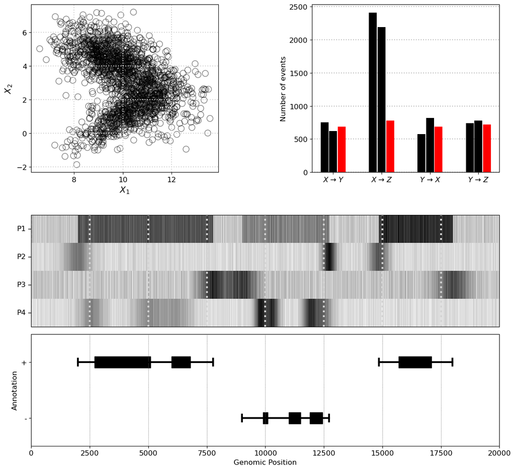

```python
fig = plt.figure(figsize=(12, 11))  # Sets the figure size

gs = GridSpec(4, 2, figure=fig, height_ratios=[.6, 0.1, .4, .4])  # Creates GridSpec layout with specified height ratios

# Plotting each component in its respective GridSpec position
ax1 = fig.add_subplot(gs[0, 0])  # Adds a subplot in the first cell of GridSpec
scatter_plot(df_scatter, ax1)  # Calls scatter_plot function with df_scatter and ax1

ax2 = fig.add_subplot(gs[0, 1])  # Adds a subplot in the second cell of GridSpec
grouped_bar_plot(df_barplot, ax2)  # Calls grouped_bar_plot function with df_barplot and ax2

ax3 = fig.add_subplot(gs[2, :])  # Adds a subplot spanning the third row of GridSpec
heatmap_annotations(df_signals, df_annotations, [ax3, fig.add_subplot(gs[3, :])])  # Calls heatmap_annotations

plt.subplots_adjust(hspace=0.07, wspace=0.5)  # Adjusts the space between subplots

plt.show()  # Displays the figure
```

## 4. Exercise 4

Loading the data set for the line plot:

```python
df_line = pd.read_csv('10_project_data_lineplots.csv') # Data for line plot
```

Creating the plot:

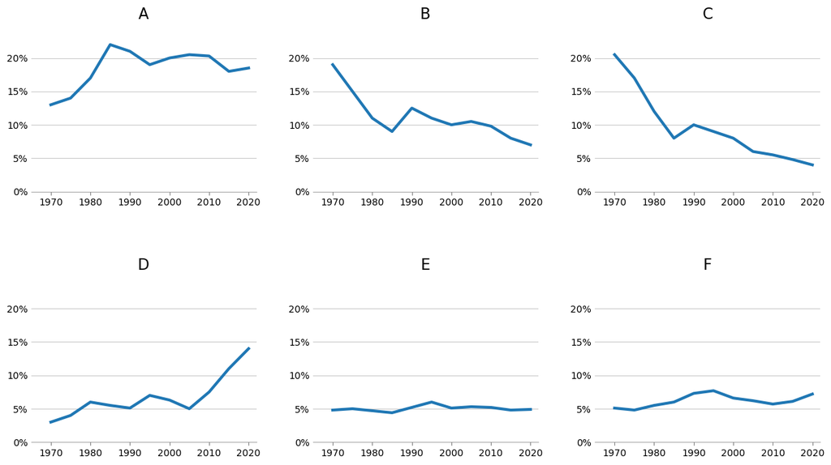

```python
fig, axes = plt.subplots(2, 3, figsize=(15, 8))  # Creates a figure with 2 rows, 3 columns of subplots

# List of columns to plot and their corresponding subplot positions
columns = ['A', 'B', 'C', 'D', 'E', 'F']
positions = [(0, 0), (0, 1), (0, 2), (1, 0), (1, 1), (1, 2)]

# Plot each column in the corresponding subplot
for col, pos in zip(columns, positions):
    ax = axes[pos]  # Selects the subplot at position pos
    ax.plot(df_line['years'], df_line[col], linestyle='-', linewidth=3)  # Plots data from df_line for column col
    ax.set_title(col, fontsize=16)  # Sets title of the subplot to col
    ax.set_ylim(0, 25)  # Sets y-axis limits from 0-25
    ax.set_yticks([0, 5, 10, 15, 20])  # Sets y-axis ticks at specified positions
    ax.set_xlim(1965, 2022)  # Sets x-axis limits from 1965 to 2022
    ax.set_xticks([1970, 1980, 1990, 2000, 2010, 2020])  # Sets x-axis ticks at 10-year intervals
    ax.grid(True, axis='y', linestyle='-', linewidth=0.5)  # Shows horizontal grid lines on y-axis
    ax.spines['top'].set_visible(False)  # Hides top spine of the subplot
    ax.spines['right'].set_visible(False)  # Hides right spine of the subplot
    ax.spines['left'].set_visible(False)  # Hides left spine of the subplot
    ax.spines['bottom'].set_color('grey')  # Sets color of bottom spine to grey
    ax.spines['bottom'].set_linewidth(0.5)  # Sets width of bottom spine
    ax.tick_params(axis='y', length=0)  # Removes y-axis ticks
    ax.tick_params(axis='both', labelsize=10)  # Sets label size for both axes
    ax.tick_params(axis='x', color='grey')  # Sets color of x-axis ticks

    # Manually setting y-axis labels with percentages
    y_ticks = [0, 5, 10, 15, 20]
    ax.set_yticklabels([f'{tick}%' for tick in y_ticks])  # Sets formatted labels for y-axis ticks

plt.subplots_adjust(hspace=0.5, wspace=0.25)  # Adjusts vertical and horizontal spacing between subplots

plt.show()  # Displays the plot
```

## 5. Exercise 4

Loading DNA sequences from the file:

```python
data_dnaseq = '10_project_data_dna_sequences.txt'  # Specifies file containing DNA sequences
with open(data_dnaseq, 'r') as file:  # Opens the file in read mode
    sequences = [line.strip() for line in file.readlines()]  # Reads each line, strips whitespace, and stores in list sequences
```

Creating the plot:

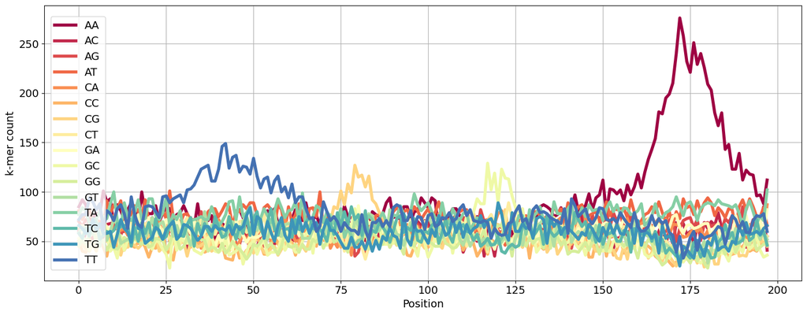

```python
# Function to count k-mer occurrences at each position
def count_kmers(sequences, k=2):
    kmer_counts = defaultdict(lambda: np.zeros(len(sequences[0]) - k + 1, dtype=int))  # Initializes defaultdict with arrays for k-mer counts at each position
    for seq in sequences:
        for i in range(len(seq) - k + 1):
            kmer = seq[i:i+k]  # Extracts k-mer from sequence
            kmer_counts[kmer][i] += 1  # Increments count for k-mer at position i
    return kmer_counts  # Returns defaultdict containing k-mer counts

# Counting the 2-mers
kmer_counts = count_kmers(sequences, k=2)  # Calls count_kmers function to count 2-mers in sequences

# Creating a dataframe for easier plotting
df_counts = pd.DataFrame(kmer_counts)

# Sorting k-mers alphabetically
sorted_kmers = sorted(df_counts.columns)

# Defining a diverging color palette
color_palette = colormaps.get_cmap('Spectral')  # Gets a colormap 'Spectral'
colors = [color_palette(i / len(sorted_kmers)) for i in range(len(sorted_kmers))]  # Generates colors from colormap
color_dict = {kmer: colors[i] for i, kmer in enumerate(sorted_kmers)}  # Creates a dictionary mapping k-mer to color

# Creating a figure and axis
fig, ax = plt.subplots(figsize=(15, 6))

# Plotting the results up to position 198
for kmer in sorted_kmers:
    ax.plot(df_counts.index[:198], df_counts[kmer][:198],  # Plots k-mer counts up to position 198
            label=kmer, color=color_dict[kmer], linewidth=4)  # Specifies label, color, and linewidth for each plot

# Setting labels and grid
ax.set_xlabel('Position')  # Sets x-axis label
ax.set_ylabel('k-mer count')  # Sets y-axis label
ax.grid(True)  # Shows grid lines

# Placing the legend inside the plot, to the left side
ax.legend(loc='upper left', bbox_to_anchor=(0.001, 0.98), fontsize=14, ncol=1)

fig.tight_layout()  # Adjusts subplot parameters to fit figure area

plt.show()
```